# Python libs for Raster Processing

The open geospatial Python ecosystem has powerful libraries for processing vector data. We have seen the likes of `geopandas`, `pyshp`, `shapely`, `folium`, `fiona`, `pysal` etc. How about for raster data processing? This notebook explores a few of them, starting with `rasterio`. My understanding so far is, in general digital image and signal processing via Python is a well established field. Thus if a library allows you to read geospatial image formats into `numpy` arrays and write the results back, you can easily accomplish your processing using standard Pythonic data analysis process of reading into `numpy` arrays, doing filtering, enhancements, analysis and presisting into the native file format of choice.

Let us see how far this theory holds up.

## Accessing raster files

```python
import rasterio
import matplotlib.pyplot as plt
%matplotlib inline
```

```python
raster = rasterio.open(path='/Users/atma6951/Documents/GIS_data/Imagery/open-geo/Helsinki_masked_p188r018_7t20020529_z34__LV-FIN.tif')
type(raster)
```

```
rasterio._io.RasterReader
```

Let us query a few important properties to understand the image better

```python
raster.crs
```

```
CRS({'proj': 'tmerc', 'lat_0': 0, 'lon_0': -183, 'k': 0.9996, 'x_0': 500000, 'y_0': 0, 'datum': 'WGS84', 'units': 'm', 'no_defs': True})
```

```python
raster.shape
```

```
(1439, 1288)
```

```python
raster.bounds
```

```
BoundingBox(left=698592.0, bottom=6656859.0, right=735300.0, top=6697870.5)
```

```python
raster.count
```

```
7
```

```python
raster.profile
```

```
{'driver': 'GTiff',
 'dtype': 'uint8',
 'nodata': None,
 'width': 1288,
 'height': 1439,
 'count': 7,
 'crs': CRS({'proj': 'tmerc', 'lat_0': 0, 'lon_0': -183, 'k': 0.9996, 'x_0': 500000, 'y_0': 0, 'datum': 'WGS84', 'units': 'm', 'no_defs': True}),
 'transform': (698592.0, 28.5, 0.0, 6697870.5, 0.0, -28.5),
 'affine': Affine(28.5, 0.0, 698592.0,
        0.0, -28.5, 6697870.5),
 'tiled': False,
 'interleave': 'pixel'}
```

### Read individual bands

```python
band1 = raster.read([1])
type(band1)
```

```
numpy.ndarray
```

```python
band1.shape, band1.ndim
```

```
((1, 1439, 1288), 3)
```

```python
band1.min(), band1.max(), band1.mean()
```

```
(0, 255, 59.63132232528628)
```

#### Read into a specified shape

I am unable to get this into a 2D array no matter what. Could be a bug

```python
band1a = raster.read([1], out_shape=(raster.profile['width'], raster.profile['height']))
band1a.reshape(1288, 1439)
band1a.shape
```

```
(1, 1288, 1439)
```

### Preview the band

```python
band1a
```

```
array([[[0, 0, 0, ..., 0, 0, 0],
        [0, 0, 0, ..., 0, 0, 0],
        [0, 0, 0, ..., 0, 0, 0],
        ...,
        [0, 0, 0, ..., 0, 0, 0],
        [0, 0, 0, ..., 0, 0, 0],
        [0, 0, 0, ..., 0, 0, 0]]], dtype=uint8)
```

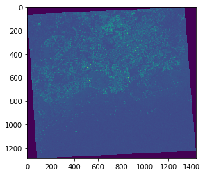

```python
from rasterio.plot import show
show(band1a)
```

Making a FCC or TCC

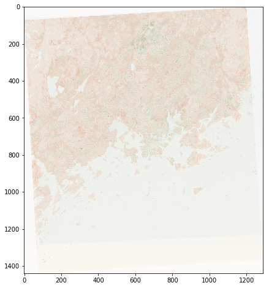

```python
fig, ax = plt.subplots(figsize=(8,8))
show(band1a, cmap='Blues', ax=ax, alpha=0.33)
show(raster.read(3), cmap='Greens', ax=ax, alpha=0.33)
show(raster.read(4), cmap="Reds", ax=ax, alpha=0.33)
```

### Plotting histograms

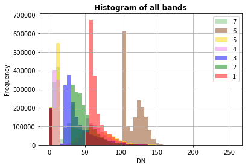

```python
from rasterio.plot import show_hist
show_hist(source=raster, bins=50, title='Histogram of all bands',
          histtype='stepfilled', alpha=0.5)
```

### Read all bands into a 3D array

```python
all_bands = raster.read()
all_bands.shape
```

```
(7, 1439, 1288)
```

```python
all_bands.ndim
```

```
3
```

## Retrieving pixel values

Get pixel values in band 1 at X,Y: `(717389, 6675310)`

```python
x,y = 717389, 6675310
array_coords = raster.index(x, y)
array_coords
```

```
(791, 659)
```

This array coordinates is the same for all bands as the dimensions of all bands is the same. Thus you can use regular array indexing as shown below to get the pixel values:

```python
band1[0,791,659]
```

```
83
```

### Retrieving pixel values across all bands.

Let us define a function that returns the pixel values across all bands

```python
[all_bands[i,array_coords[0], array_coords[1]] for
 i in range(raster.count)]
```

```
[83, 62, 66, 32, 53, 139, 48]
```

```python
def get_cell_value(raster, all_bands, x,y):
    array_coords = raster.index(x,y)
    n_bands = raster.count

    # get pixel values
    values= [all_bands[i, array_coords[0], array_coords[1]]
            for i in range(raster.count)]

    # plot values
    plt.plot(values)
    return values
```

You can use this to construct spectral profiles of various points.

```
[68, 50, 42, 12, 12, 116, 11]
```

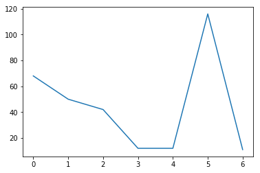

```python
get_cell_value(raster, all_bands, 702829, 6685820)
```

```
[69, 60, 47, 102, 87, 133, 42]
```

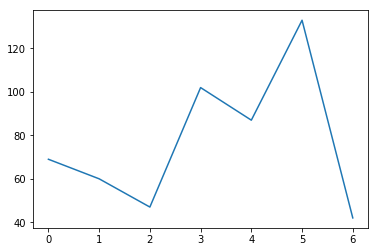

```python
get_cell_value(raster, all_bands, 713891, 6688037)
```

Comparing this with QGIS, the values and charts are consistent.